# Final Project Hawaii

Katie B

3/4/2020

# Option 4: Point Pattern and Area Analyses of AirBNB Prices in Hawaii

### For the final project, I decided that doing a cost analysis of price-per-night listings would be beneficial for the purpose of researching potential places to stay for my honeymoon in 2021. Before I can jump into the research, I will start by loading and organizing everything necessary for data manipulation.

```r
# packages for Spatial Point Interpolation
library(gstat)
library(maptools)
# packages for Spatial Regression
library(GWmodel)
library(RColorBrewer)

# misc. packages I believe may be helpful
library(ggmap)
library(jsonlite)
library(gapminder)
library(GISTools)
library(tmap)
library(tidyverse)
library(raster)
library(spatstat)
library(mapview)
library(spDataLarge)
library(ggplot2)
```

Reading in my listings and GIS data for HI as a points object and polygons object:

```r
listings <- read.csv(file = "http://data.insideairbnb.com/united-states/hi/hawaii/2020-02-12/visualisations/listings.csv", header = TRUE)

head(listings)
```

```
##     id                                             name host_id host_name
## 1 5065                                         MAUKA BB    7257     Wayne
## 2 5269        Upcountry Hospitality in the 'Auwai Suite    7620 Lea & Pat
## 3 5387              Hale Koa Studio & 1 Bedroom Units!!    7878    Edward
## 4 5389                                    Keauhou Villa    7878    Edward
## 5 5390                            STAY AT PRINCE KUHIO!    7887      Todd
## 6 5434 Kauai  Ocean View 3 Story Tiki Tower North Shore    7984     Ahlea
##   neighbourhood_group     neighbourhood latitude longitude       room_type
## 1              Hawaii           Hamakua 20.04095 -155.4325 Entire home/apt
## 2              Hawaii      South Kohala 20.02621 -155.7014 Entire home/apt
## 3              Hawaii        South Kona 19.43119 -155.8808 Entire home/apt
## 4              Hawaii        North Kona 19.56413 -155.9635 Entire home/apt
## 5               Kauai       Koloa-Poipu 21.88305 -159.4737 Entire home/apt
## 6               Kauai North Shore Kauai 22.21972 -159.4696 Entire home/apt
##   price minimum_nights number_of_reviews last_review reviews_per_month
## 1    85              2                37  2019-08-19              0.44
## 2   110              2                 9  2019-10-20              0.08
## 3    92              5               165  2020-01-07              1.36
## 4   299              6                19  2020-01-28              0.25
## 5    92              3               135  2020-01-19              1.03
## 6   290              3               106  2020-01-21              0.83
##   calculated_host_listings_count availability_365
## 1                              2              360
## 2                              4              260
## 3                              3              310
## 4                              3              199
## 5                              1              109
## 6                              2              270
```

```r
dim(listings)
```

```
## [1] 24120    16
```

I have to choose one room type to analyze, so I’m going to make a filtered dataset with just ‘Entire home/apt’:

```r
# It seemed that this was the only portion of the 'filtering' code chunk from HW3 that was applicable here
listings_homes <- listings %>% filter (listings$room_type == "Entire home/apt")

head(listings_homes)
```

```
##     id                                             name host_id host_name
## 1 5065                                         MAUKA BB    7257     Wayne
## 2 5269        Upcountry Hospitality in the 'Auwai Suite    7620 Lea & Pat
## 3 5387              Hale Koa Studio & 1 Bedroom Units!!    7878    Edward
## 4 5389                                    Keauhou Villa    7878    Edward
## 5 5390                            STAY AT PRINCE KUHIO!    7887      Todd
## 6 5434 Kauai  Ocean View 3 Story Tiki Tower North Shore    7984     Ahlea
##   neighbourhood_group     neighbourhood latitude longitude       room_type
## 1              Hawaii           Hamakua 20.04095 -155.4325 Entire home/apt
## 2              Hawaii      South Kohala 20.02621 -155.7014 Entire home/apt
## 3              Hawaii        South Kona 19.43119 -155.8808 Entire home/apt
## 4              Hawaii        North Kona 19.56413 -155.9635 Entire home/apt
## 5               Kauai       Koloa-Poipu 21.88305 -159.4737 Entire home/apt
## 6               Kauai North Shore Kauai 22.21972 -159.4696 Entire home/apt
##   price minimum_nights number_of_reviews last_review reviews_per_month
## 1    85              2                37  2019-08-19              0.44
## 2   110              2                 9  2019-10-20              0.08
## 3    92              5               165  2020-01-07              1.36
## 4   299              6                19  2020-01-28              0.25
## 5    92              3               135  2020-01-19              1.03
## 6   290              3               106  2020-01-21              0.83
##   calculated_host_listings_count availability_365
## 1                              2              360
## 2                              4              260
## 3                              3              310
## 4                              3              199
## 5                              1              109
## 6                              2              270
```

```r
dim(listings_homes)
```

```
## [1] 21311    16
```

Convert the polygons object into sf object:

```r
library(sf)
bnb_hawaii <- st_read("C:/Users/kbaer/Desktop/Katie/Spatial & GIS (Spring A 2020)/neighbourhoods.geojson")
class(bnb_hawaii)
```

```
## [1] "sf"         "data.frame"
```

Now convert the polygons object into sp:

```r
bnb_hawaii <- lwgeom::st_make_valid(bnb_hawaii)
bnb_hawaii <- as(bnb_hawaii, "Spatial")

class(bnb_hawaii)
```

```
## [1] "SpatialPolygonsDataFrame"
## attr(,"package")
## [1] "sp"
```

In order to set the CRS for my objects, I still need to transform my data points into sp as well:

```r
### PROF PHAM EXAMPLE SP ###
coordinates(listings_homes)<-~longitude+latitude
class(listings_homes)
```

```
## [1] "SpatialPointsDataFrame"
## attr(,"package")
## [1] "sp"
```

```r
proj4string(listings_homes)
```

```
## [1] NA
```

```r
proj4string(listings_homes)<-CRS("+init=epsg:4326")

proj4string(listings_homes)
```

```
## [1] "+init=epsg:4326 +proj=longlat +datum=WGS84 +no_defs +ellps=WGS84 +towgs84=0,0,0"
```

```r
proj4string(bnb_hawaii)
```

```
## [1] "+proj=longlat +datum=WGS84 +no_defs +ellps=WGS84 +towgs84=0,0,0"
```

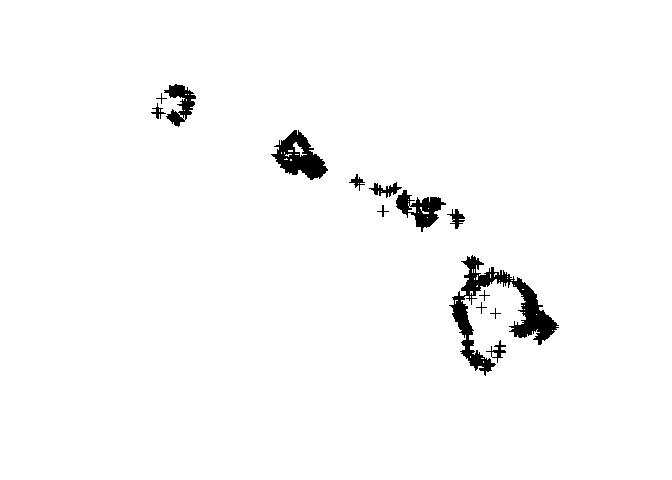

```r
plot(listings_homes)
```

### Map all the listings by neighborhood for one room type. I’ve chosen Entire Homes/Apts for my analysis.

Using basic plot() function:

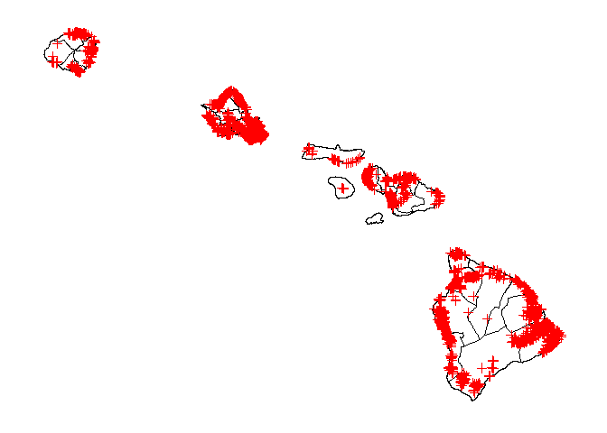

```r
par(mar=c(1,1,1,1))
plot(bnb_hawaii)
plot(listings_homes, col="red",add=TRUE)
```

Using tmap() function:

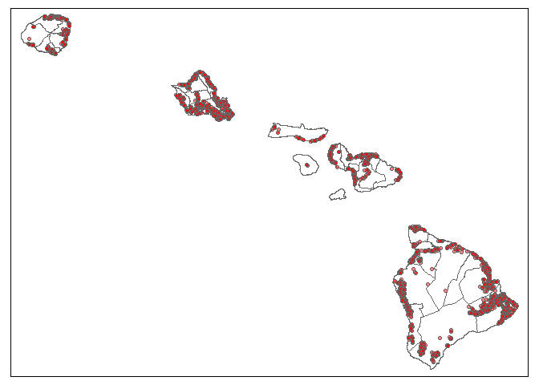

```r
tm_shape(bnb_hawaii) +
  tm_borders() +
tm_shape(listings_homes) +
  tm_dots(col="red", size = 0.1, shape = 21, alpha = 0.5)
```

Now I have to put my objects on a projected CRS in order to carry out the rest of the assignment:

```r
listings_homes_proj <- spTransform(listings_homes, CRS("+init=epsg:2782"))
proj4string(listings_homes_proj)
```

```
## [1] "+init=epsg:2782 +proj=tmerc +lat_0=18.83333333333333 +lon_0=-155.5 +k=0.999966667 +x_0=500000 +y_0=0 +ellps=GRS80 +towgs84=0,0,0,0,0,0,0 +units=m +no_defs"
```

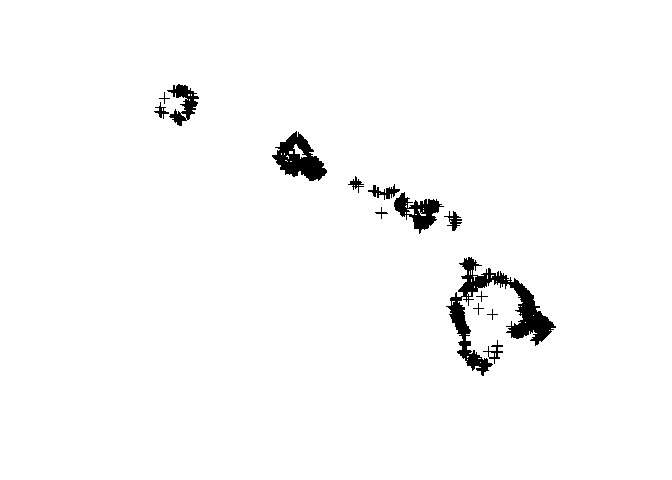

```r
plot(listings_homes_proj)
```

```r
bnb_hawaii_proj <- spTransform(bnb_hawaii, CRS(proj4string(listings_homes_proj)))
proj4string(bnb_hawaii_proj)
```

```
## [1] "+init=epsg:2782 +proj=tmerc +lat_0=18.83333333333333 +lon_0=-155.5 +k=0.999966667 +x_0=500000 +y_0=0 +ellps=GRS80 +towgs84=0,0,0,0,0,0,0 +units=m +no_defs"
```

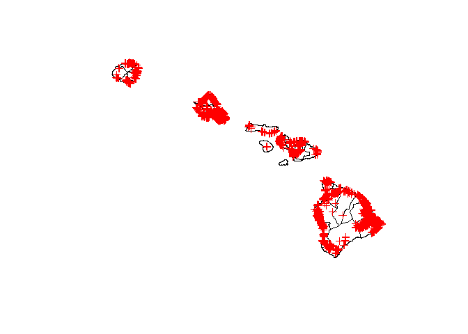

```r
plot(bnb_hawaii_proj)
plot(listings_homes_proj, col="red", add=TRUE)
```

### Apply spatial interpolation methods to estimate the price (per night) for the same room type you mapped out.

Trend Surface Analysis:

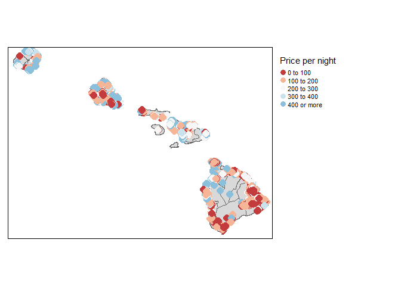

```r
P <- listings_homes_proj
W <- bnb_hawaii_proj

P@bbox <- W@bbox

tm_shape(W) + tm_polygons() +
  tm_shape(P) +
  tm_dots(col="price", palette = "RdBu", auto.palette.mapping = FALSE, breaks = c(0, 100, 200, 300, 400, Inf),
          title="Price per night", size=0.7) +
  #tm_text("price", just="left", xmod=.5, size = 0.7) +
  tm_legend(legend.outside=TRUE)
```

```r
grd              <- as.data.frame(spsample(P, "regular", n=50000))
names(grd)       <- c("X", "Y")
coordinates(grd) <- c("X", "Y")
gridded(grd)     <- TRUE  # Create SpatialPixel object
fullgrid(grd)    <- TRUE  # Create SpatialGrid object

proj4string(grd) <- proj4string(P)

f.1 <- as.formula(price ~ X + Y)

P$X <- coordinates(P)[,1]
P$Y <- coordinates(P)[,2]
```

It seems that a majority of affordable AirBNB listings for entire homes are near Hilo, which is good news since that’s where I was most interested in going if I do our honeymoon in Hawaii. I was hoping to visit Kona as well since both cities are on the Big Island, however there’s a large cluster of more-expensive stays in Kona. We may have to consider a private room instead of a house if we decide to go to Kona.

Predicting house prices:

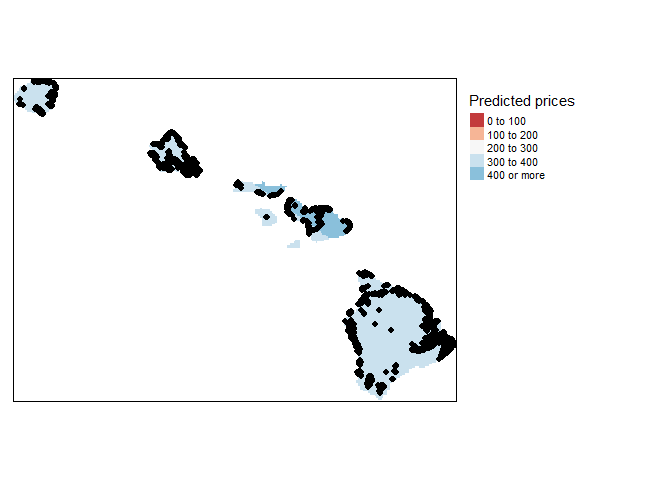

```r
# Run the regression model
lm.1 <- lm( f.1, data=P)

# Use the regression model output to interpolate the surface
dat.1st <- SpatialGridDataFrame(grd, data.frame(var1.pred = predict(lm.1, newdata=grd)))

library(raster)
r   <- raster(dat.1st)
r.m <- mask(r, W)

tm_shape(r.m) +
  tm_raster(n=5, palette="RdBu",breaks=c(0, 100, 200, 300, 400, Inf),
            title="Predicted prices") +
  tm_shape(P) + tm_dots(size=0.2) +
  tm_legend(legend.outside=TRUE)
```

### Estimate a global multiple linear regression models to predict price per night. Discuss your model.

Assessing pricing stats:

```r
mean(listings_homes_proj$price) #global mean price
```

```
## [1] 378.6564
```

```r
sd(listings_homes_proj$price) #global standard deviation
```

```
## [1] 837.4468
```

```r
localstats1 <- gwss(listings_homes_proj, vars = c("price",
                                          "minimum_nights"), bw=50000)
```

I decided to look at this as price by minimum nights required as a predictor:

```r
head(data.frame(localstats1$SDF))
```

```
##   price_LM minimum_nights_LM price_LSD minimum_nights_LSD price_LVar
## 1 343.4647          4.822427  901.4502          15.388604   812612.5
## 2 656.3897          3.647009 1342.7340           6.762973  1802934.6
## 3 285.1838          3.458994  683.2381           5.653475   466814.4
## 4 344.2095          3.452072  885.8192           5.777052   784675.7
## 5 414.2958          2.800373  499.8013           5.178027   249801.4
## 6 364.1351          3.132376  458.4286           6.484290   210156.8
##   minimum_nights_LVar price_LSKe minimum_nights_LSKe price_LCV
## 1           236.80914  13.173703           10.072298  2.624579
## 2            45.73780   7.610644           15.202431  2.045635
## 3            31.96177  23.588446            8.779286  2.395782
## 4            33.37433  14.798965            9.023715  2.573489
## 5            26.81197   7.022568           29.515059  1.206388
## 6            42.04602   8.209632           23.681137  1.258952
##   minimum_nights_LCV Cov_price.minimum_nights Corr_price.minimum_nights
## 1           3.191050               -428.05018              -0.030753980
## 2           1.854389               -539.03241              -0.059308300
## 3           1.634427                 11.46484               0.002966665
## 4           1.673503                -81.48100              -0.015915325
## 5           1.849049                -14.65198              -0.005659035
## 6           2.070087                335.47058               0.112804800
##   Spearman_rho_price.minimum_nights longitude  latitude optional
## 1                       0.130954177 507060.57 133676.97     TRUE
## 2                       0.007715696 478923.00 132056.50     TRUE
## 3                       0.034017997 460011.36  66220.95     TRUE
## 4                       0.025948552 451368.32  80958.32     TRUE
## 5                      -0.077758574  89103.71 342936.38     TRUE
## 6                       0.087254306  90505.22 380268.59     TRUE
```

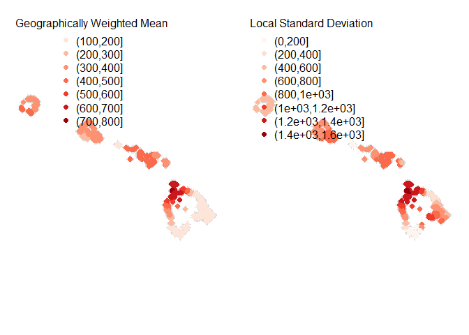

```r
plot.new()
quick.map <- function(spdf,var,legend.title,main.title) {
  x <- spdf@data[,var]
  cut.vals <- pretty(x)
  x.cut <- cut(x,cut.vals)
  cut.levels <- levels(x.cut)
  cut.band <- match(x.cut,cut.levels)
  colors <- brewer.pal(length(cut.levels),'Reds')
  par(mar=c(1,1,1,1))
  plot(listings_homes_proj,col='grey85')
  #title(main.title)
  plot(spdf,add=TRUE,col=colors[cut.band],pch=16)
  legend('topleft',cut.levels,col=colors,pch=16,bty='n',title=legend.title)
}

plot.new()
par(mfrow=c(1,2))
quick.map(localstats1$SDF, "price_LM", "Geographically Weighted Mean")

quick.map(localstats1$SDF, "price_LSD","Local Standard Deviation")
```

```r
gwr.res <- gwr.basic(price~minimum_nights,
                     data=listings_homes_proj,bw=50000, kernel='gaussian')
gwr.res
```

```
##    *                       Package   GWmodel                             *
##    Program starts at: 2020-03-08 18:31:25
##    Call:
##    gwr.basic(formula = price ~ minimum_nights, data = listings_homes_proj,
##     bw = 50000, kernel = "gaussian")
##
##    Dependent (y) variable:  price
##    Independent variables:  minimum_nights
##    Number of data points: 21311
##    *                    Results of Global Regression                     *
##
##    Call:
##     lm(formula = formula, data = data)
##
##    Residuals:
##     Min      1Q  Median      3Q     Max
##  -384.0  -234.0  -156.5   -16.7 24651.9
##
##    Coefficients:
##                   Estimate Std. Error t value Pr(>|t|)
##    (Intercept)    385.2746     6.4308  59.911   <2e-16 ***
##    minimum_nights  -1.2727     0.5591  -2.276   0.0228 *
##
##    ---Significance stars
##    Signif. codes:  0 '***' 0.001 '**' 0.01 '*' 0.05 '.' 0.1 ' ' 1
##    Residual standard error: 837.4 on 21309 degrees of freedom
##    Multiple R-squared: 0.0002431
##    Adjusted R-squared: 0.0001962
##    F-statistic: 5.182 on 1 and 21309 DF,  p-value: 0.02283
##    ***Extra Diagnostic information
##    Residual sum of squares: 14941434148
##    Sigma(hat): 837.3646
##    AIC:  347339.1
##    AICc:  347339.1
##    *          Results of Geographically Weighted Regression              *
##
##    *********************Model calibration information*********************
##    Kernel function: gaussian
##    Fixed bandwidth: 50000
##    Regression points: the same locations as observations are used.
##    Distance metric: Euclidean distance metric is used.
##
##    ****************Summary of GWR coefficient estimates:******************
##                        Min.   1st Qu.    Median   3rd Qu.    Max.
##    Intercept      203.10057 328.99446 383.42576 426.69379 487.936
##    minimum_nights  -4.64625  -1.43315  -0.58537   1.85352   5.286
##    ************************Diagnostic information*************************
##    Number of data points: 21311
##    Effective number of parameters (2trace(S) - trace(S'S)): 12.29374
##    Effective degrees of freedom (n-2trace(S) + trace(S'S)): 21298.71
##    AICc (GWR book, Fotheringham, et al. 2002, p. 61, eq 2.33): 347127.5
##    AIC (GWR book, Fotheringham, et al. 2002,GWR p. 96, eq. 4.22): 347115.3
##    Residual sum of squares: 14782415389
##    R-square value:  0.01088334
##    Adjusted R-square value:  0.01031238
##
##    Program stops at: 2020-03-08 18:33:12
```

My first model really didn’t tell me anything. My r squared and p values are extremely low, and AIC scores are very high, which seems to demonstrate that a listing’s minimum required # of nights does not really have any predictive properties of price per night. In my second regression, I’ll test another numeric variable to try and predict price.

### Examine at least two geographically weighted multiple linear regression models to predict price per night. Discuss your preferred model.

```r
localstats2 <- gwss(listings_homes_proj, vars = c("price",
                                          "availability_365"), bw=50000)
head(data.frame(localstats2$SDF))
```

```
##   price_LM availability_365_LM price_LSD availability_365_LSD price_LVar
## 1 343.4647            219.7449  901.4502            106.23443   812612.5
## 2 656.3897            221.6831 1342.7340             88.93167  1802934.6
## 3 285.1838            198.9977  683.2381            103.63715   466814.4
## 4 344.2095            198.9677  885.8192            103.84140   784675.7
## 5 414.2958            204.1795  499.8013             90.87207   249801.4
## 6 364.1351            197.8229  458.4286            102.45923   210156.8
##   availability_365_LVar price_LSKe availability_365_LSKe price_LCV
## 1             11285.754  13.173703            -0.5805722  2.624579
## 2              7908.842   7.610644            -0.8199689  2.045635
## 3             10740.658  23.588446            -0.5376958  2.395782
## 4             10783.036  14.798965            -0.5457868  2.573489
## 5              8257.734   7.022568            -0.7250413  1.206388
## 6             10497.893   8.209632            -0.5445863  1.258952
##   availability_365_LCV Cov_price.availability_365 Corr_price.availability_365
## 1            0.4834445                  2929.9183                  0.03049272
## 2            0.4011658                  7938.1598                  0.06642042
## 3            0.5207957                  -952.8103                 -0.01344952
## 4            0.5219008                  2404.3329                  0.02612700
## 5            0.4450596                  3190.6294                  0.07021926
## 6            0.5179341                  4055.3316                  0.08630002
##   Spearman_rho_price.availability_365 longitude  latitude optional
## 1                         0.060431221 507060.57 133676.97     TRUE
## 2                         0.106862937 478923.00 132056.50     TRUE
## 3                         0.009677974 460011.36  66220.95     TRUE
## 4                         0.036053578 451368.32  80958.32     TRUE
## 5                         0.050947370  89103.71 342936.38     TRUE
## 6                         0.138946144  90505.22 380268.59     TRUE
```

```r
gwr.res2 <- gwr.basic(price~availability_365,
                     data=listings_homes_proj,bw=50000, kernel='gaussian')
gwr.res2
```

```
##    *                       Package   GWmodel                             *
##    Program starts at: 2020-03-08 18:38:21
##    Call:
##    gwr.basic(formula = price ~ availability_365, data = listings_homes_proj,
##     bw = 50000, kernel = "gaussian")
##
##    Dependent (y) variable:  price
##    Independent variables:  availability_365
##    Number of data points: 21311
##    *                    Results of Global Regression                     *
##
##    Call:
##     lm(formula = formula, data = data)
##
##    Residuals:
##     Min      1Q  Median      3Q     Max
##  -380.7  -235.0  -157.2   -15.5 24639.8
##
##    Coefficients:
##                      Estimate Std. Error t value Pr(>|t|)
##    (Intercept)      359.15604   12.73548  28.201   <2e-16 ***
##    availability_365   0.09727    0.05671   1.715   0.0864 .
##
##    ---Significance stars
##    Signif. codes:  0 '***' 0.001 '**' 0.01 '*' 0.05 '.' 0.1 ' ' 1
##    Residual standard error: 837.4 on 21309 degrees of freedom
##    Multiple R-squared: 0.000138
##    Adjusted R-squared: 9.109e-05
##    F-statistic: 2.941 on 1 and 21309 DF,  p-value: 0.08636
##    ***Extra Diagnostic information
##    Residual sum of squares: 14943005007
##    Sigma(hat): 837.4086
##    AIC:  347341.4
##    AICc:  347341.4
##    *          Results of Geographically Weighted Regression              *
##
##    *********************Model calibration information*********************
##    Kernel function: gaussian
##    Fixed bandwidth: 50000
##    Regression points: the same locations as observations are used.
##    Distance metric: Euclidean distance metric is used.
##
##    ****************Summary of GWR coefficient estimates:******************
##                          Min.   1st Qu.    Median   3rd Qu.     Max.
##    Intercept        226.54108 232.15789 324.30371 513.49377 533.0606
##    availability_365  -0.51096  -0.41815   0.39855   0.44931   0.5013
##    ************************Diagnostic information*************************
##    Number of data points: 21311
##    Effective number of parameters (2trace(S) - trace(S'S)): 12.38809
##    Effective degrees of freedom (n-2trace(S) + trace(S'S)): 21298.61
##    AICc (GWR book, Fotheringham, et al. 2002, p. 61, eq 2.33): 347066.2
##    AIC (GWR book, Fotheringham, et al. 2002,GWR p. 96, eq. 4.22): 347053.8
##    Residual sum of squares: 14739665916
##    R-square value:  0.01374378
##    Adjusted R-square value:  0.0131701
##
##    Program stops at: 2020-03-08 18:40:12
```

This was slightly better, but still didn’t perform very well. My next logical step would be to evaluate how I can put non-numeric features into the regression, since it seems I may have much better predictors of price in my data than what I’ve tested.

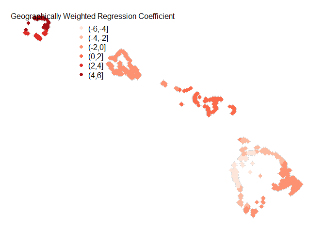

```r
quick.map(gwr.res$SDF,"minimum_nights",
          "Geographically Weighted Regression Coefficient")
```

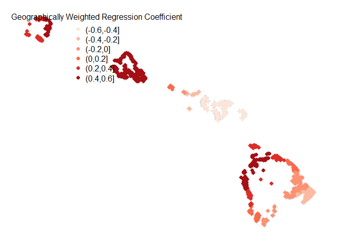

```r
quick.map(gwr.res2$SDF,"availability_365",
          "Geographically Weighted Regression Coefficient")
```